Tholonia - 590-J-Structured_Water  
The Existential Mechanics of Awareness  
Duncan Stroud  
Published: January 15, 2020  
Updated: Updated: Jan 1, 2026  
Welkin Wall Publishing  
ISBN-10:  
ISBN-13: 978-1-6780-2532-8  
Copyright ©2020 Duncan Stroud CC BY-NC-SA 4.0

# Appendix J: Structuring Water

###### Some additional information for the curious

I personally experienced results similar to those reported in the animal studies. In my own experiments, I created SW simply by spinning 1 liter of water with a chemical stirrer in a magnetic field generated by 6 equidistant, opposing magnets glued to the outside of the water jar, which was about 6 inches wide at its widest point. Each magnet (15mm x 3mm NbFeB 42 MGOe) has a strength of 2,335 Gauss at the closest point inside the jug, which drops to 3 Gauss at the center of the jar, 3 inches from the magnet, and which drops to about 8 Gauss in between the magnets (which are about 3.5 inches apart each). These are a bit weak, considering a magnetic field strength of 1,000 to 3,000 Gauss is typically cited as effective for water treatment, but the Gauss drops below 1,000 after 7 mm inside the jar. The water is spinning, so all the water is exposed to the stronger fields, but as it is constantly rotating, that exposure is temporary.

This was the only water I drank for close to a year, and neither my diet nor lifestyle changed in any significant manner during that time. The difference between the before and after blood tests was consistent with the results from animal tests. My blood panel was generally better regarding cholesterol levels, but the most dramatic change was my triglycerides dropped from 750 mg/dL to 150 mg/dL. While this is purely anecdotal and could be influenced by numerous unmeasured variables, the fact that my results matched those of controlled animal tests was enough for me to accept that structured water merits serious scientific study.

### Making Structured Water

We look at three ways to create structured water.

Before we get into the techniques, there is an important point to make: if you are reading this, you have obviously maintained an open mind and a level of interest, which are prerequisites for the following topic.

As we have mentioned, ideas have archetypes, and those archetypes have instances. One of the archetypes of Ideas is form. This would then suggest that ideas can alter archetypes of form, which can alter an instance of form. Tholonically speaking, that is exactly right. The mere thought of something has some effect on the instantiated form of that thought.

This is relevant to creating structured water or any creative process, but water seems particularly sensitive to it. The thoughts you impose on the water affect it. While the scientific support for this claim is still being collected, evaluated, and debated, from a purely tholonic perspective, it is a valid hypothesis that focusing your awareness on water will have some effect. Also, in accordance with tholonic ideas, increasing the structure of water will create a better medium for energetic interaction.

**Manually**

Vortexing (whirlpooling) water by hand was shown to be effective at reducing growth differences in plant tests, but it is not easily scalable. It is fairly easy to create a vortex in a container of water using small tubes and a water pump, or a chemical stirrer that spins a magnet inside the water.

There also does not seem to be a standardized accepted technique for manually structuring water. One technique that seems popular is a homemade version of the same method used in some industrial-sized units: simply using marbles as a water filter.

The reasoning behind using marbles is that the natural structure of water that is reinforced by its movement over and through the terrain, rivers, rocks, trees, etc., is destroyed by being processed, stored in stationary reserves, channeled through pipes, chemically modified, and a number of other modifiers. Simply flowing water over and through a marble filter causes it to form many small eddies as it is constantly divided and reunited, allowing it to return (closer) to its natural, more structured state.

People have reported favorable results by simply filling a glass tube with glass marbles, pouring water into one end, and collecting it at the other. The process can be repeated numerous times or placed inline with a water pump vortexer. If marbles work, then using the same reasoning, a sand filter would probably work even better. The Centers for Disease Control has an entire page on sand filters (https://www.cdc.gov/safewater/sand-filtration.html).

Anything that forces water to reform itself is thought to have some effect. Some people say using quartz helps. Tholonically, this would make sense as we claim that structure is the result of order, order is the result of energy, energy has fields, and fields have induction.

Magnets have also been used. Although it may make sense to use magnets, no one seems to explain them well. The intuitive reasoning is simply that magnets are fields caused by order; therefore, magnetic fields can induce order. Some of Australia’s largest produce farms have been using magnetic water with phenomenal results, needing 25% less water to produce a superior product than with traditional water, according to Seven West Media, Western Australia’s leading news service.[^1]

Simple instructions can be found on the web[^2] for making a Hero’s Fountain (named after the first-century Greek mathematician Heron, who discovered the energy-free recycling process for water fountains) that recycles water through a loop. Fill one of the bottles with marbles, or whatever you like, and when the cycle is complete, you have a bottle filled with restructured water.

**Commercial Attachments**

Devices such as the Martin-Wasserwirbler (MW) attachment are small devices that claim to restructure water, typically by creating a vortex within the device. The Martin-Wasserwirbler (developed in Germany) is an attachment that forces the water through a series of vortex-creating channels made of oppositely charged metals. I am slightly suspicious of this last bit, as they say they use silver and gold as oppositely charged metals, but both have similar ionization and electronegativity properties, so unless they are doing something to these metals to change that, it’s not clear how they can be oppositely charged. This is not to say they are not, just that it is unclear.

The MW device was the first to create structured water and was based on the ideas originally conceived by the brilliant Viktor Schauberger, the Austrian forest caretaker, naturalist, parascientist, philosopher, inventor, and biomimicry experimenter, and his son, Walter Schauberger, both of whom studied the qualities of water.[^3]

Tests with the MWV have shown positive results, including increases in pH and oxygen content and a decline in water temperature. Unfortunately, there are no tools to measure many of the qualities of water that we believe are its most important: how it moves, stores, and transmits energy, including the energy of awareness.

**Industrial Solutions**

Pursanova designs and manufactures a complete water-processing system for residential, commercial, and industrial applications. Their products range from $20 to many thousands. They have a number of case studies on their website (pursanova.com), which are astounding.

*Disclaimer: I have no relationship with any of these companies and am not promoting any of their products. I refer to them simply because my research indicates they are legitimate products in an industry filled with wild and dubious claims.*

Below are the tests I ran myself. Tests *(j)* and *(k)* were run numerous times with the same results. The results showed that the SW had a clear effect on disintegrating the material more quickly and thoroughly. This suggests that the SW had a lower entropy/higher energy potential than the CW.

I suspect this is due to hydrogen bonds, which have various lengths, directions, and strengths, and which can change and even break with kinetic energy and movement.

We know that formation of hydrogen bonds in water can have large effects on the water’s entropy, and that even small changes to water’s entropy can have a considerable influence[^5].

Hydrogen bonds in water remain a matter of ongoing scientific debate, particularly regarding their role in inducing persistent structural changes in bulk water.

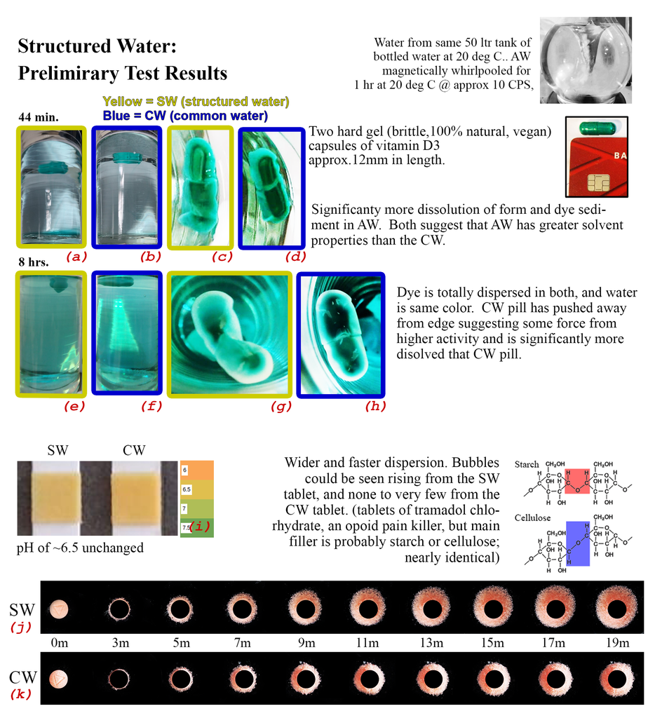

[^1]: The use of magnetic water in agriculture to increase harvest and save up to 25% water. Live testimonials by the biggest Australian farmers. https://www.youtube.com/watch?v=YVL6tfGhr8M
[^2]: For example. **Heron’s Fountain Plastic Water Bottle 2 minute DIY no sealant, no glue,**https://www.youtube.com/watch?v=92rSXLPupKw
[^3]: More on Victor’s work can be seen in the excellent documentary on YouTube “**The Secrets of Water, The Documentary of Viktor Schauberger / Comprehend and Copy Nature**”, https://www.youtube.com/watch?v=XyOGdjWDVM4
[^4]: Martin-Fischer-Harthun, “**Experimente mit Leitungswasser**”, 1997. This paper is difficult to find online. The original can be purchased at https://www.fischer-wirbelwasser.de/shop/buecher.html
[^5]: Martin.chaplin@btinternet.com, Martin Chaplin: “**Hydrogen bonding in water**”. Accessed December 8, 2022. http://water.lsbu.ac.uk/water/water_hydrogen_bonding.html.